# 家庭外籍看護工——勞動待遇面面觀

# 8. 雇主休假意願：誰說不？

## 8.1 休假意願總覽

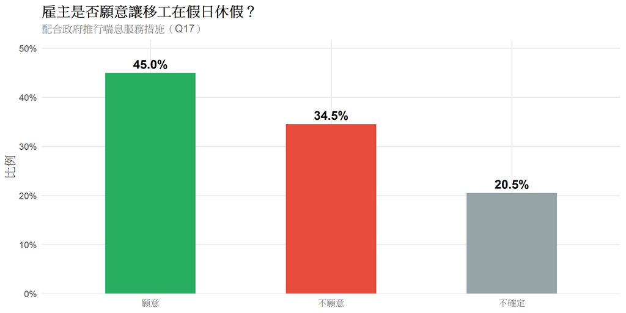

```r
df %>%
  filter(!is.na(願意休假)) %>%
  count(願意休假, wt = 權重) %>%
  mutate(pct = n / sum(n)) %>%
  ggplot(aes(x = 願意休假, y = pct, fill = 願意休假)) +
  geom_col(width = 0.5, show.legend = FALSE) +
  geom_text(aes(label = percent(pct, accuracy = 0.1)),
            vjust = -0.5, fontface = "bold", size = 5) +
  scale_fill_manual(values = c("願意" = "#27AE60", "不願意" = "#E74C3C",
                                "不確定" = "#95A5A6")) +
  scale_y_continuous(labels = percent, expand = expansion(mult = c(0, 0.15))) +
  labs(title = "雇主是否願意讓移工在假日休假？",
       subtitle = "配合政府推行喘息服務措施（Q17）",
       x = NULL, y = "比例")
```

## 8.2 休假意願 × 放假現況（交叉檢驗）

[figure not shown]

```r
df %>%
  filter(!is.na(願意休假), !is.na(放假情形)) %>%
  mutate(
    放假簡化 = fct_collapse(放假情形,
      "有放假" = c("都有放假(4-5次/月)", "每月1次", "每月2-3次"),
      "完全不放假" = "完全不放假"
    )
  ) %>%
  count(放假簡化, 願意休假, wt = 權重) %>%
  group_by(放假簡化) %>%
  mutate(pct = n / sum(n)) %>%
  ggplot(aes(x = 放假簡化, y = pct, fill = 願意休假)) +
  geom_col(width = 0.6) +
  geom_text(aes(label = percent(pct, accuracy = 0.1)),
            position = position_stack(vjust = 0.5), size = 4, fontface = "bold") +
  scale_fill_manual(values = c("願意" = "#27AE60", "不願意" = "#E74C3C",
                                "不確定" = "#95A5A6")) +
  scale_y_continuous(labels = percent) +
  labs(title = "目前完全不放假的雇主，更不願意讓移工休假",
       subtitle = "放假現況 × 休假意願的交叉比較",
       caption = "這顯示「不放假」可能不只是現實限制，也反映雇主的態度傾向",
       x = NULL, y = "比例") +
  theme(legend.title = element_blank())
```

# 9. 勞動待遇的連鎖效應：迴歸分析

> 前面各節分別觀察了單一待遇面向的影響。 這裡用迴歸模型**同時控制多項待遇變項**，看哪些是真正重要的預測因子。

## 9.1 逃跑的預測因子（Logistic 迴歸）

```r
model_run <- glm(
  逃跑_01 ~ 月薪 + 每日工時 + 放假情形 + 薪資支付 + 有保險 +
             護理訓練 + 有輪替 + 薪資明細,
  data = df, family = binomial, weights = 權重
)

tidy(model_run, conf.int = TRUE, exponentiate = TRUE) %>%
  mutate(across(where(is.numeric), ~ round(., 3))) %>%
  kable(caption = "逃跑 Logistic 迴歸（勝算比 OR）— 勞動待遇作為預測變項")
```

逃跑 Logistic 迴歸（勝算比 OR）— 勞動待遇作為預測變項

| term | estimate | std.error | statistic | p.value | conf.low | conf.high |
| --- | --- | --- | --- | --- | --- | --- |
| (Intercept) | 0.143 | 0.219 | -8.874 | 0.000 | 0.093 | 0.220 |
| 月薪 | 1.000 | 0.000 | -7.488 | 0.000 | 1.000 | 1.000 |
| 每日工時 | 0.961 | 0.008 | -5.152 | 0.000 | 0.947 | 0.976 |
| 放假情形每月1次 | 1.600 | 0.065 | 7.280 | 0.000 | 1.413 | 1.820 |
| 放假情形每月2-3次 | 1.504 | 0.070 | 5.819 | 0.000 | 1.313 | 1.729 |
| 放假情形完全不放假 | 1.483 | 0.068 | 5.817 | 0.000 | 1.301 | 1.696 |
| 薪資支付匯入銀行 | 0.642 | 0.059 | -7.509 | 0.000 | 0.571 | 0.720 |
| 薪資支付其他（部分匯款/仲介） | 0.559 | 0.083 | -6.979 | 0.000 | 0.473 | 0.656 |
| 有保險無 | 1.150 | 0.025 | 5.485 | 0.000 | 1.094 | 1.209 |
| 護理訓練無訓練 | 1.555 | 0.027 | 16.447 | 0.000 | 1.475 | 1.639 |
| 有輪替無 | 0.716 | 0.036 | -9.257 | 0.000 | 0.667 | 0.768 |
| 薪資明細有（僅中文） | 0.773 | 0.038 | -6.765 | 0.000 | 0.717 | 0.833 |
| 薪資明細沒有提供 | 0.915 | 0.059 | -1.511 | 0.131 | 0.813 | 1.025 |

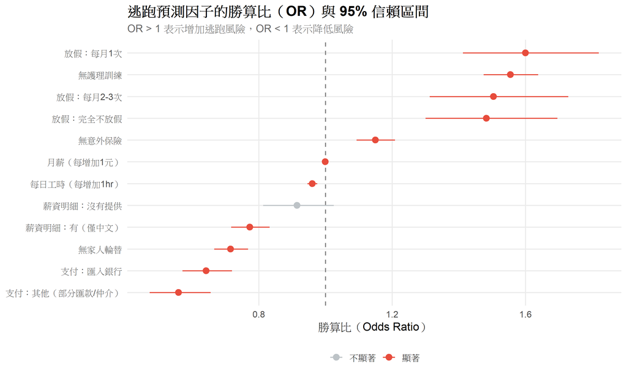

```r
tidy(model_run, conf.int = TRUE, exponentiate = TRUE) %>%
  filter(term != "(Intercept)") %>%
  mutate(
    term = str_replace_all(term, c(
      "月薪" = "月薪（每增加1元）",
      "每日工時" = "每日工時（每增加1hr）",
      "放假情形" = "放假：",
      "薪資支付" = "支付：",
      "有保險無" = "無意外保險",
      "護理訓練無訓練" = "無護理訓練",
      "有輪替無" = "無家人輪替",
      "薪資明細" = "薪資明細："
    )),
    sig = ifelse(p.value < 0.05, "顯著", "不顯著")
  ) %>%
  ggplot(aes(x = estimate, y = reorder(term, estimate), color = sig)) +
  geom_vline(xintercept = 1, linetype = "dashed", color = "grey50") +
  geom_pointrange(aes(xmin = conf.low, xmax = conf.high), size = 0.6) +
  scale_color_manual(values = c("顯著" = "#E74C3C", "不顯著" = "#BDC3C7")) +
  labs(title = "逃跑預測因子的勝算比（OR）與 95% 信賴區間",
       subtitle = "OR > 1 表示增加逃跑風險，OR < 1 表示降低風險",
       x = "勝算比（Odds Ratio）", y = NULL) +
  theme(legend.title = element_blank())
```

## 9.2 雇主困擾的預測因子（Logistic 迴歸）

```r
model_trouble <- glm(
  困擾_01 ~ 月薪 + 每日工時 + 放假情形 + 薪資支付 + 有保險 +
             護理訓練 + 有輪替 + 薪資明細,
  data = df, family = binomial, weights = 權重
)

tidy(model_trouble, conf.int = TRUE, exponentiate = TRUE) %>%
  mutate(across(where(is.numeric), ~ round(., 3))) %>%
  kable(caption = "雇主困擾 Logistic 迴歸（勝算比 OR）— 勞動待遇作為預測變項")
```

雇主困擾 Logistic 迴歸（勝算比 OR）— 勞動待遇作為預測變項

| term | estimate | std.error | statistic | p.value | conf.low | conf.high |
| --- | --- | --- | --- | --- | --- | --- |
| (Intercept) | 1.008 | 0.085 | 0.089 | 0.929 | 0.853 | 1.191 |
| 月薪 | 1.000 | 0.000 | -16.822 | 0.000 | 1.000 | 1.000 |
| 每日工時 | 0.994 | 0.003 | -1.900 | 0.057 | 0.988 | 1.000 |
| 放假情形每月1次 | 1.627 | 0.024 | 19.918 | 0.000 | 1.551 | 1.707 |
| 放假情形每月2-3次 | 1.357 | 0.027 | 11.310 | 0.000 | 1.288 | 1.431 |
| 放假情形完全不放假 | 1.918 | 0.026 | 25.425 | 0.000 | 1.824 | 2.017 |
| 薪資支付匯入銀行 | 0.947 | 0.020 | -2.703 | 0.007 | 0.911 | 0.985 |
| 薪資支付其他（部分匯款/仲介） | 0.752 | 0.028 | -10.339 | 0.000 | 0.712 | 0.793 |
| 有保險無 | 0.920 | 0.010 | -8.320 | 0.000 | 0.902 | 0.938 |
| 護理訓練無訓練 | 2.235 | 0.011 | 72.734 | 0.000 | 2.187 | 2.284 |
| 有輪替無 | 0.924 | 0.014 | -5.753 | 0.000 | 0.900 | 0.949 |
| 薪資明細有（僅中文） | 0.804 | 0.015 | -15.054 | 0.000 | 0.781 | 0.827 |
| 薪資明細沒有提供 | 0.860 | 0.023 | -6.590 | 0.000 | 0.823 | 0.900 |

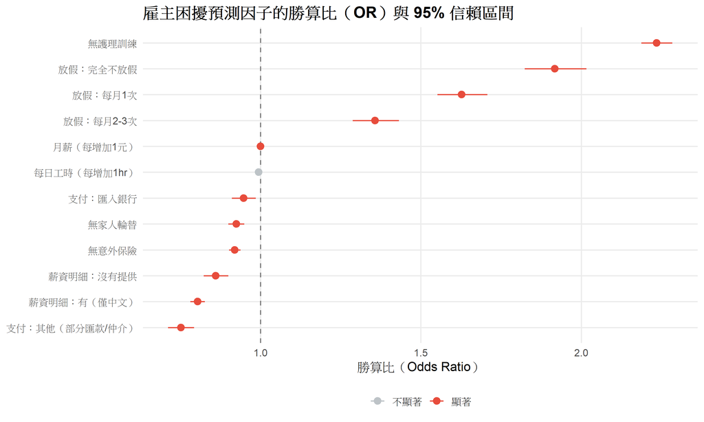

```r
tidy(model_trouble, conf.int = TRUE, exponentiate = TRUE) %>%
  filter(term != "(Intercept)") %>%
  mutate(
    term = str_replace_all(term, c(
      "月薪" = "月薪（每增加1元）",
      "每日工時" = "每日工時（每增加1hr）",
      "放假情形" = "放假：",
      "薪資支付" = "支付：",
      "有保險無" = "無意外保險",
      "護理訓練無訓練" = "無護理訓練",
      "有輪替無" = "無家人輪替",
      "薪資明細" = "薪資明細："
    )),
    sig = ifelse(p.value < 0.05, "顯著", "不顯著")
  ) %>%
  ggplot(aes(x = estimate, y = reorder(term, estimate), color = sig)) +
  geom_vline(xintercept = 1, linetype = "dashed", color = "grey50") +
  geom_pointrange(aes(xmin = conf.low, xmax = conf.high), size = 0.6) +
  scale_color_manual(values = c("顯著" = "#E74C3C", "不顯著" = "#BDC3C7")) +
  labs(title = "雇主困擾預測因子的勝算比（OR）與 95% 信賴區間",
       x = "勝算比（Odds Ratio）", y = NULL) +
  theme(legend.title = element_blank())
```

## 9.3 滿意度的預測因子（OLS 迴歸）

```r
model_sat <- lm(
  整體滿意 ~ 月薪 + 每日工時 + 放假情形 + 薪資支付 + 有保險 +
              護理訓練 + 有輪替 + 薪資明細,
  data = df, weights = 權重
)

tidy(model_sat, conf.int = TRUE) %>%
  mutate(across(where(is.numeric), ~ round(., 4))) %>%
  kable(caption = "整體滿意度 OLS 迴歸 — 勞動待遇作為預測變項（分數越低越滿意）")
```

整體滿意度 OLS 迴歸 — 勞動待遇作為預測變項（分數越低越滿意）

| term | estimate | std.error | statistic | p.value | conf.low | conf.high |
| --- | --- | --- | --- | --- | --- | --- |
| (Intercept) | 2.6889 | 0.1893 | 14.2047 | 0.0000 | 2.3178 | 3.0600 |
| 月薪 | 0.0000 | 0.0000 | -5.2296 | 0.0000 | -0.0001 | 0.0000 |
| 每日工時 | -0.0165 | 0.0068 | -2.4067 | 0.0161 | -0.0299 | -0.0031 |
| 放假情形每月1次 | 0.2333 | 0.0503 | 4.6398 | 0.0000 | 0.1347 | 0.3319 |
| 放假情形每月2-3次 | 0.2123 | 0.0560 | 3.7928 | 0.0002 | 0.1025 | 0.3220 |
| 放假情形完全不放假 | 0.2069 | 0.0534 | 3.8763 | 0.0001 | 0.1022 | 0.3115 |
| 薪資支付匯入銀行 | -0.0876 | 0.0446 | -1.9632 | 0.0497 | -0.1751 | -0.0001 |
| 薪資支付其他（部分匯款/仲介） | -0.0834 | 0.0598 | -1.3957 | 0.1629 | -0.2006 | 0.0338 |
| 有保險無 | 0.0088 | 0.0228 | 0.3858 | 0.6997 | -0.0359 | 0.0535 |
| 護理訓練無訓練 | 0.3209 | 0.0259 | 12.3697 | 0.0000 | 0.2700 | 0.3717 |
| 有輪替無 | -0.0703 | 0.0313 | -2.2459 | 0.0248 | -0.1317 | -0.0089 |
| 薪資明細有（僅中文） | -0.0270 | 0.0324 | -0.8337 | 0.4045 | -0.0905 | 0.0365 |
| 薪資明細沒有提供 | -0.0768 | 0.0500 | -1.5349 | 0.1249 | -0.1749 | 0.0213 |

```r
cat("R² =", round(summary(model_sat)$r.squared, 4),
    "| Adj R² =", round(summary(model_sat)$adj.r.squared, 4), "\n")
```

```
## R² = 0.0545 | Adj R² = 0.0516
```

# 10. 關鍵發現摘要

```r
tibble(
  發現 = c(
    "薪資集中於法定下限",
    "護理訓練未反映在薪資上",
    "護理訓練大幅降低困擾率",
    "四成移工完全不放假",
    "給假的雇主困擾率反而最低",
    "近九成以現金支付薪資",
    "現金支付逃跑率最高",
    "有輪替照顧逃跑率反而更高",
    "僅半數有商業意外保險",
    "性別平等假幾乎無人申請"
  ),
  數據 = c(
    "中位數 20,000 元，75% ≤ 22,000",
    "有訓練 21,098 vs 無訓練 21,206",
    "有訓練 29.1% vs 無訓練 47.5%",
    "完全不放假佔 41.4%",
    "都有放假 21.6% vs 不放假 37.0%",
    "現金 88.8%",
    "現金 3.8% vs 銀行 2.4% vs 其他 2.1%",
    "有輪替 4.0% vs 無輪替 2.9%",
    "投保率約 48.7%",
    "僅 47/4016（1.2%）曾提出需求"
  ),
  性質 = c(
    "結構性問題", "反常", "重要發現",
    "結構性問題", "反常", "結構性問題",
    "值得關注", "反常", "保障不足", "制度落差"
  )
) %>%
  kable(caption = "十大關鍵發現", align = c("l", "l", "c"))
```

十大關鍵發現

[output not shown]

# 11. 後續分析方向

```r
cat("
### 建議延伸

**1. 因果推論強化**
上述迴歸僅反映相關性。若要更嚴謹地估計「給假是否降低逃跑率」，
可考慮工具變數法（IV）或傾向分數配對（PSM），以處理遺漏變數偏誤。

**2. 地區差異**
變項 `j1` 含縣市代碼，可將待遇面向按地區分組，
觀察都會/非都會區的薪資、工時、放假差異。

**3. 聚類分析**
將雇主依「薪資 × 休假 × 保險 × 薪資透明度」進行 K-means 或潛在類別分析，
辨認出不同類型的雇用模式（如「高保障型」vs.「最低合規型」）。

**4. 困擾原因的深入交叉**
第 6 題的 11 項困擾原因（Q6a_1 ～ Q6a_11）可進一步依護理訓練、
放假情形等分群，找出特定待遇條件下最突出的困擾類型。

**5. 時間趨勢**
若能取得歷年資料，可比較各年度待遇指標的變化趨勢，
評估政策介入（如直聘推廣、喘息服務補助）的效果。
")
```

### 建議延伸

**1. 因果推論強化** 上述迴歸僅反映相關性。若要更嚴謹地估計「給假是否降低逃跑率」， 可考慮工具變數法（IV）或傾向分數配對（PSM），以處理遺漏變數偏誤。

**2. 地區差異** 變項 `j1` 含縣市代碼，可將待遇面向按地區分組， 觀察都會/非都會區的薪資、工時、放假差異。

**3. 聚類分析** 將雇主依「薪資 × 休假 × 保險 × 薪資透明度」進行 K-means 或潛在類別分析， 辨認出不同類型的雇用模式（如「高保障型」vs.「最低合規型」）。

**4. 困擾原因的深入交叉** 第 6 題的 11 項困擾原因（Q6a_1 ～ Q6a_11）可進一步依護理訓練、 放假情形等分群，找出特定待遇條件下最突出的困擾類型。

**5. 時間趨勢** 若能取得歷年資料，可比較各年度待遇指標的變化趨勢， 評估政策介入（如直聘推廣、喘息服務補助）的效果。

*本報告由 R Markdown 自動生成｜資料來源：勞動部「移工管理及運用調查」113 年家庭面問卷*